# Week1-day3

[figure not shown]

### **LEARNING OBJECTIVES**

- Import and inspect real-world tabular data
- Identify and handle missing values, duplicates, and outliers
- Subset and filter rows based on logical conditions
- Select specific columns or index ranges efficiently
- Group data and compute aggregations
- Engineer a new categorical income variable
- Generate comprehensive descriptive statistics

### **1. DATA IMPORTATION**

#### **Why it matters:**

- CSV is the universal standard for tabular data
- Pandas read_csv() handles parsing, type inference, and header alignment
- Proper import prevents downstream errors in cleaning and analysis
- Key parameters: sep, header, na_values, dtype

```python
import pandas as pd
import numpy as np

# Load the dataset
df = pd.read_csv('GSSsubset1.csv')
df.head()
```

|  | id | sex | degree | income | marital | age | height | weight | hrswrk |
| --- | --- | --- | --- | --- | --- | --- | --- | --- | --- |
| 0 | 1 | MALE | HIGH SCHOOL | 26722.56 | NEVER MARRIED | 18 | 73.2 | 86.3 | 35.0 |
| 1 | 2 | MALE | NaN | 36544.91 | MARRIED | 35 | 69.9 | 95.3 | 47.0 |
| 2 | 3 | FEMALE | HIGH SCHOOL | 59587.14 | DIVORCED | 28 | 70.1 | 60.9 | 16.0 |
| 3 | 4 | FEMALE | GRADUATE | NaN | MARRIED | 43 | 61.9 | 76.0 | 44.0 |
| 4 | 5 | MALE | HIGH SCHOOL | 48899.47 | MARRIED | 48 | 65.8 | 58.9 | 44.0 |

```python
# Verify successful import
print(f"Shape: {df.shape}")
print(f"Columns: {df.columns.tolist()}")
```

```
Shape: (3000, 9)
Columns: ['id', 'sex', 'degree', 'income', 'marital', 'age', 'height', 'weight', 'hrswrk']
```

### **2. INITIAL DATA INSPECTION**

- .info() reveals memory footprint and missing values
- .describe() gives numeric summaries
- .value_counts() shows category frequencies

This trio is your first diagnostic checkpoint before any cleaning begins

```python
print("\n" + "="*60)
print("DATA INSPECTION")
print("="*60)
# Data types, non-null counts, memory usage
print("\n[1] DataFrame Info:")
print(df.info())
```

```
============================================================
DATA INSPECTION
============================================================

[1] DataFrame Info:
<class 'pandas.core.frame.DataFrame'>
RangeIndex: 3000 entries, 0 to 2999
Data columns (total 9 columns):
 #   Column   Non-Null Count  Dtype
---  ------   --------------  -----
 0   id       3000 non-null   int64
 1   sex      3000 non-null   object
 2   degree   2942 non-null   object
 3   income   2767 non-null   float64
 4   marital  2934 non-null   object
 5   age      3000 non-null   int64
 6   height   3000 non-null   float64
 7   weight   2879 non-null   float64
 8   hrswrk   2933 non-null   float64
dtypes: float64(4), int64(2), object(3)
memory usage: 211.1+ KB
None
```

```python
print("\n" + "="*60)
print("DESCRIPTIVE STATISTICS")
print("="*60)
# Quick statistical summary for numeric columns
print("\n[2] Statistical Summary (Numeric):")
df.drop(columns=["id"]).describe()
```

```
============================================================
DESCRIPTIVE STATISTICS
============================================================

[2] Statistical Summary (Numeric):
```

|  | income | age | height | weight | hrswrk |
| --- | --- | --- | --- | --- | --- |
| count | 2767.000000 | 3000.000000 | 3000.000000 | 2879.000000 | 2933.000000 |
| mean | 63871.815790 | 42.078000 | 67.400500 | 76.389232 | 39.778043 |
| std | 51634.075898 | 13.314316 | 3.641297 | 14.584233 | 12.594723 |
| min | 3720.040000 | 18.000000 | 58.100000 | 45.000000 | 0.000000 |
| 25% | 31989.025000 | 33.000000 | 64.600000 | 65.800000 | 34.000000 |
| 50% | 49586.540000 | 42.000000 | 67.200000 | 75.700000 | 41.000000 |
| 75% | 78986.595000 | 51.000000 | 70.100000 | 85.700000 | 48.000000 |
| max | 609741.180000 | 80.000000 | 78.600000 | 120.000000 | 79.000000 |

```python
print("\n" + "="*60)
print("FREQUENCIES FOR CATEGORICAL VARIABLES")
print("="*60)
# Check categorical value distributions
print("\n[3] Education Level Distribution:")
print(df['degree'].value_counts())

print("\n[4] Marital Status Distribution:")
print(df['marital'].value_counts())

print("\n[5] Gender Distribution:")
print(df['sex'].value_counts())
```

```
============================================================
FREQUENCIES FOR CATEGORICAL VARIABLES
============================================================

[3] Education Level Distribution:
degree
HIGH SCHOOL       1094
LT HIGH SCHOOL     583
BACHELOR           566
JUNIOR COLLEGE     465
GRADUATE           234
Name: count, dtype: int64

[4] Marital Status Distribution:
marital
MARRIED          1518
NEVER MARRIED     691
DIVORCED          382
WIDOWED           227
SEPARATED         116
Name: count, dtype: int64

[5] Gender Distribution:
sex
FEMALE    1563
MALE      1437
Name: count, dtype: int64
```

```python
def freq_table(df, column):
    # Frequency
    freq = df[column].value_counts(dropna=False)

    # Percentage
    percent = df[column].value_counts(normalize=True, dropna=False) * 100

    # Cumulative %
    cum_percent = percent.cumsum()

    # Combine into one table
    table = pd.DataFrame({
        'Frequency': freq,
        'Percent (%)': percent.round(2),
        'Cumulative (%)': cum_percent.round(2)
    })

    return table
```

```python
print("\n[3] Education Level Distribution:")
freq_table(df, 'degree')
```

```
[3] Education Level Distribution:
```

| degree | Frequency | Percent (%) | Cumulative (%) |
| --- | --- | --- | --- |
| HIGH SCHOOL | 1094 | 36.47 | 36.47 |
| LT HIGH SCHOOL | 583 | 19.43 | 55.90 |
| BACHELOR | 566 | 18.87 | 74.77 |
| JUNIOR COLLEGE | 465 | 15.50 | 90.27 |
| GRADUATE | 234 | 7.80 | 98.07 |
| NaN | 58 | 1.93 | 100.00 |

```python
print("\n[4] Marital Status Distribution:")
freq_table(df, 'marital')
```

```
[4] Marital Status Distribution:
```

| marital | Frequency | Percent (%) | Cumulative (%) |
| --- | --- | --- | --- |
| MARRIED | 1518 | 50.60 | 50.60 |
| NEVER MARRIED | 691 | 23.03 | 73.63 |
| DIVORCED | 382 | 12.73 | 86.37 |
| WIDOWED | 227 | 7.57 | 93.93 |
| SEPARATED | 116 | 3.87 | 97.80 |
| NaN | 66 | 2.20 | 100.00 |

```python
print("\n[5] Gender Distribution:")
freq_table(df, 'sex')
```

```
[5] Gender Distribution:
```

| sex | Frequency | Percent (%) | Cumulative (%) |
| --- | --- | --- | --- |
| FEMALE | 1563 | 52.1 | 52.1 |
| MALE | 1437 | 47.9 | 100.0 |

### **3. DATA CLEANING: MISSING VALUES**

- Missing data appears as NaN, None, or placeholders (?, -99)
- Causes: survey non-response, data entry errors, system drops
- Impact: skews statistics, breaks algorithms, reduces sample size
- Strategy: Detect → Decide (Drop / Impute / Flag)

```python
print("\n" + "="*60)
print("MISSING VALUES ANALYSIS")
print("="*60)

# Count missing per column
print("\n[1] Missing values per column:")
print(df.isna().sum())

# Percentage of missing data
missing_pct = df.isna().mean().round(4) * 100
print("\n[2] Missing percentage per column:")
print(missing_pct[missing_pct > 0])
```

```
============================================================
MISSING VALUES ANALYSIS
============================================================

[1] Missing values per column:
id           0
sex          0
degree      58
income     233
marital     66
age          0
height       0
weight     121
hrswrk      67
dtype: int64

[2] Missing percentage per column:
degree     1.93
income     7.77
marital    2.20
weight     4.03
hrswrk     2.23
dtype: float64
```

#### **Visual check (optional - requires seaborn)**

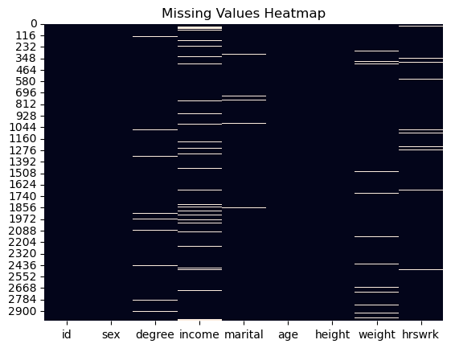

```python
import seaborn as sns
import matplotlib.pyplot as plt
sns.heatmap(df.isnull(), cbar=False)
plt.title("Missing Values Heatmap")
plt.show()
```

#### **Bar Chart for Missing Values for Each Variable**

```python
# Load required libraries
import pandas as pd
import numpy as np
import matplotlib.pyplot as plt
import seaborn as sns
from matplotlib.patches import Patch
import warnings
warnings.filterwarnings('ignore')
```

```python
# Set style
sns.set_style("whitegrid")
plt.rcParams['figure.figsize'] = [10, 6]
plt.rcParams['font.size'] = 10
```

```python
# =============================================================================
# 2. CALCULATE MISSING VALUES PER VARIABLE
# =============================================================================

# Function to calculate missing value statistics
def calculate_missing(data):
    missing_summary = pd.DataFrame({
        'Variable': data.columns,
        'Missing_Count': [data[col].isna().sum() for col in data.columns],
        'Total_Count': len(data)
    })

    # Calculate percentage missing
    missing_summary['Missing_Pct'] = round(
        100 * missing_summary['Missing_Count'] / missing_summary['Total_Count'], 2
    )

    # Order by missing count (descending) for better visualization
    missing_summary = missing_summary.sort_values('Missing_Count', ascending=False).reset_index(drop=True)

    return missing_summary

# Generate missing value summary
missing_df = calculate_missing(df)

# Print summary to console
print("\n=== MISSING VALUES SUMMARY ===")
print(missing_df)
print(f"\nTotal variables: {len(missing_df)}")
print(f"Variables with missing data: {(missing_df['Missing_Count'] > 0).sum()}")
```

```
=== MISSING VALUES SUMMARY ===
  Variable  Missing_Count  Total_Count  Missing_Pct
0   income            233         3000         7.77
1   weight            121         3000         4.03
2   hrswrk             67         3000         2.23
3  marital             66         3000         2.20
4   degree             58         3000         1.93
5       id              0         3000         0.00
6      sex              0         3000         0.00
7      age              0         3000         0.00
8   height              0         3000         0.00

Total variables: 9
Variables with missing data: 5
```

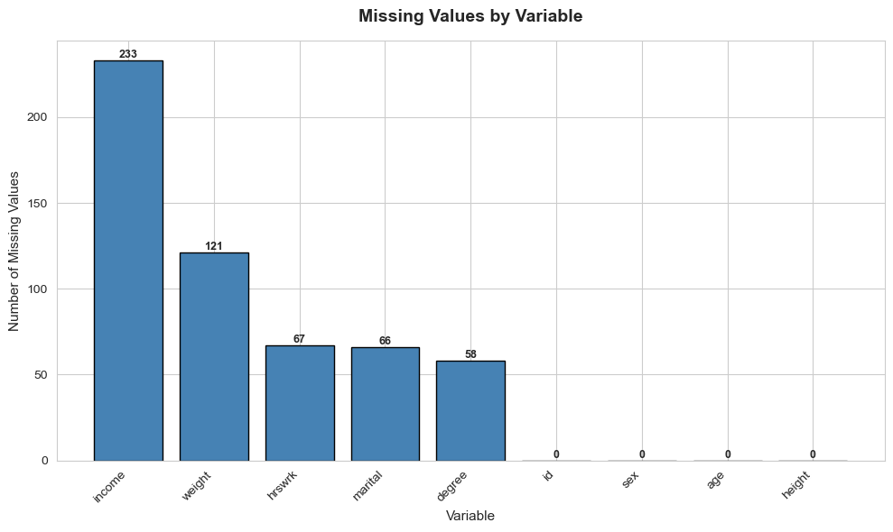

```python
# =============================================================================
# 3. CREATE BAR CHART - OPTION 1: Basic matplotlib/seaborn
# =============================================================================

# Basic bar chart (counts)
fig, ax = plt.subplots(figsize=(10, 6))
bars = ax.bar(missing_df['Variable'], missing_df['Missing_Count'],
              color='steelblue', edgecolor='black', linewidth=1)

# Add count labels on top of bars
for bar in bars:
    height = bar.get_height()
    ax.text(bar.get_x() + bar.get_width()/2., height,
            f'{int(height)}',
            ha='center', va='bottom', fontsize=9, fontweight='bold')

ax.set_title('Missing Values by Variable', fontsize=14, fontweight='bold', pad=15)
#ax.set_subtitle('GSSsubset Dataset (n = 3,000)', fontsize=10, color='gray')
ax.set_xlabel('Variable', fontsize=11)
ax.set_ylabel('Number of Missing Values', fontsize=11)
plt.xticks(rotation=45, ha='right')
plt.tight_layout()

# Display plot
plt.show()

# Save to file
plt.savefig("missing_values_count.png", dpi=300, bbox_inches='tight')
plt.close()
```

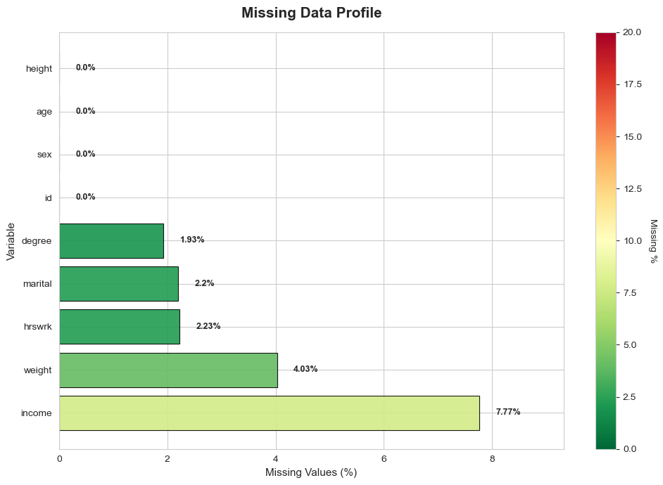

```python
# =============================================================================
# 4. CREATE BAR CHART - OPTION 2: Percentage with Color Gradient
# =============================================================================

# Enhanced chart with percentage and color coding
fig, ax = plt.subplots(figsize=(10, 7))

# Create horizontal bar chart with color gradient
colors = plt.cm.RdYlGn_r(missing_df['Missing_Pct'] / 20)  # Red-Yellow-Green gradient
bars = ax.barh(missing_df['Variable'], missing_df['Missing_Pct'],
               color=colors, edgecolor='black', linewidth=0.8, alpha=0.9)

# Add percentage labels
for i, (idx, row) in enumerate(missing_df.iterrows()):
    ax.text(row['Missing_Pct'] + 0.3, i, f"{row['Missing_Pct']}%",
            va='center', fontsize=9, fontweight='bold')

ax.set_title('Missing Data Profile', fontsize=15, fontweight='bold', pad=15)
ax.set_xlabel('Missing Values (%)', fontsize=11)
ax.set_ylabel('Variable', fontsize=11)
ax.set_xlim(0, max(missing_df['Missing_Pct']) * 1.2)

# Add colorbar legend
sm = plt.cm.ScalarMappable(cmap='RdYlGn_r',
                           norm=plt.Normalize(vmin=0, vmax=20))
sm.set_array([])
cbar = plt.colorbar(sm, ax=ax)
cbar.set_label('Missing %', rotation=270, labelpad=15)

plt.tight_layout()

# Display plot
plt.show()

# Save to file
plt.savefig("missing_values_percentage.png", dpi=300, bbox_inches='tight')
plt.close()
```

```python
# =============================================================================
# 6. SUPPLEMENTARY: MISSING VALUES TABLE FOR REPORTING
# =============================================================================

# Create formatted table for reports/manuscripts
missing_table = missing_df[missing_df['Missing_Count'] > 0].copy()

def severity_short(pct):
    if pct < 5:
        return "✓ Low"
    elif pct < 10:
        return "⚠ Moderate"
    elif pct < 20:
        return "⚠⚠ High"
    else:
        return "✗ Critical"

missing_table['Missing_Pct_Formatted'] = missing_table['Missing_Pct'].apply(lambda x: f"{x:.2f}%")
missing_table['Severity_Short'] = missing_table['Missing_Pct'].apply(severity_short)

# Select and order columns for display
missing_table_display = missing_table[['Variable', 'Missing_Count',
                                        'Missing_Pct_Formatted', 'Severity_Short']]

print("\n=== MISSING VALUES TABLE FOR REPORTING ===")
print(missing_table_display.to_string(index=False))

# Export table to CSV for documentation
missing_table_display.to_csv("missing_values_summary.csv", index=False)
print("\n✓ Missing values summary saved to: missing_values_summary.csv")
```

```
=== MISSING VALUES TABLE FOR REPORTING ===
Variable  Missing_Count Missing_Pct_Formatted Severity_Short
  income            233                 7.77%     ⚠ Moderate
  weight            121                 4.03%          ✓ Low
  hrswrk             67                 2.23%          ✓ Low
 marital             66                 2.20%          ✓ Low
  degree             58                 1.93%          ✓ Low

✓ Missing values summary saved to: missing_values_summary.csv
```

```python
#pip install missingno
```

```python
# =============================================================================
# 7. OPTIONAL: MISSING VALUES HEATMAP (Pattern Visualization)
# =============================================================================

try:
    import missingno as msno

    # Create missingness heatmap
    plt.figure(figsize=(9, 5))
    msno.bar(df, figsize=(9, 5), color='steelblue')
    plt.title('Missing Data Heatmap', fontsize=14, fontweight='bold', pad=15)
    plt.tight_layout()

    # Display plot
    plt.show()

    # Save to file
    plt.savefig("missing_heatmap.png", dpi=300, bbox_inches='tight')
    plt.close()
    print("✓ Missing heatmap saved to: missing_heatmap.png")

except ImportError:
    print("\n⚠ missingno library not installed. Install with: pip install missingno")
    print("  Skipping heatmap visualization.")
```

```
⚠ missingno library not installed. Install with: pip install missingno
  Skipping heatmap visualization.
```

```python
# =============================================================================
# 8. QUICK DIAGNOSTIC: Missing Data Patterns
# =============================================================================

print("\n=== MISSING DATA PATTERNS ===")

# Check if missingness is concentrated in specific variables
high_missing = missing_df[missing_df['Missing_Pct'] >= 5]['Variable'].tolist()

if len(high_missing) > 0:
    print(f"⚠ Variables with ≥5% missing: {', '.join(high_missing)}")
else:
    print("✓ All variables have <5% missing data (generally acceptable)")

# Check for complete cases
complete_cases = df.dropna().shape[0]
print(f"\nComplete cases (no missing in any variable): {complete_cases} ({100 * complete_cases / len(df):.1f}%)")

print("\n=== ANALYSIS COMPLETE ===")
```

```
=== MISSING DATA PATTERNS ===
⚠ Variables with ≥5% missing: income

Complete cases (no missing in any variable): 2503 (83.4%)

=== ANALYSIS COMPLETE ===
```

### **HANDLING MISSING VALUES - Multiple Strategies**

- Use dropna() cautiously: it can shrink your dataset drastically
- Imputation preserves rows but introduces bias if not documented
- Median is safer than mean for skewed data like income or weight

```python
print("\n[3] Handling Missing Values - Strategies:")

# Option 1: Drop rows with ANY missing value
df_drop_all = df.dropna()
print(f"\nOption 1 - Drop all missing: {len(df)} → {len(df_drop_all)} rows")
```

```
[3] Handling Missing Values - Strategies:

Option 1 - Drop all missing: 3000 → 2503 rows
```

#### **Standard Imputation Approach**

```python
# ==========================================
# 🔹 AUTOMATIC NUMERIC IMPUTATION (One-Liner)
# ==========================================
numeric_cols = df.select_dtypes(include='number').columns
```

```python
# Use MEDIAN (recommended for skewed data like income, weight, hrswrk)
df[numeric_cols] = df[numeric_cols].fillna(df[numeric_cols].median())

# To use MEAN instead, just swap .median() with .mean():
#df[numeric_cols] = df[numeric_cols].fillna(df[numeric_cols].mean())
```

```python
# ==========================================
# 🔹 (Optional) Handle Categorical Columns with Mode
# ==========================================
cat_cols = df.select_dtypes(include=['object', 'category']).columns
for col in cat_cols:
    mode_val = df[col].mode()
    if not mode_val.empty:
        df[col] = df[col].fillna(mode_val[0])
```

```python
# ==========================================
# ✅ VERIFY MISSING VALUES ARE RESOLVED
# ==========================================
print("Missing values after imputation:\n", df.isnull().sum())
```

```
Missing values after imputation:
 id         0
sex        0
degree     0
income     0
marital    0
age        0
height     0
weight     0
hrswrk     0
dtype: int64
```

#### **Machine Learning Approach for Imputation**

```python
from sklearn.impute import SimpleImputer
import pandas as pd

num_cols = df.select_dtypes(include='number').columns

imputer = SimpleImputer(strategy='median')  # or 'mean'
df[num_cols] = imputer.fit_transform(df[num_cols])
```

```python
# Option 2: Drop if specific column is missing
df_drop_income = df.dropna(subset=['income'])
print(f"Option 2 - Drop missing income: {len(df)} → {len(df_drop_income)} rows")
```

```
Option 2 - Drop missing income: 3000 → 3000 rows
```

#### **Best Alternative Approach**

```python
numeric_cols = df.select_dtypes(include=['float64', 'int64']).columns
for col in numeric_cols:
    if df[col].isnull().any():
        mean_value = df[col].mean()
        df[col].fillna(mean_value, inplace=True)

print("Missing values after mean imputation:")
print(df.isnull().sum())
```

```
Missing values after mean imputation:
id         0
sex        0
degree     0
income     0
marital    0
age        0
height     0
weight     0
hrswrk     0
dtype: int64
```

#### **For Categorical Variables**

```python
categorical_cols = df.select_dtypes(include='category').columns
for col in categorical_cols:
    if df[col].isnull().any():
        mode_value = df[col].mode()[0]  # .mode() can return multiple modes, take the first
        df[col].fillna(mode_value, inplace=True)

print("Missing values after mode imputation:")
print(df.isnull().sum())
```

```
Missing values after mode imputation:
id         0
sex        0
degree     0
income     0
marital    0
age        0
height     0
weight     0
hrswrk     0
dtype: int64
```

### **4. DATA CLEANING: DUPLICATES**

- Exact duplicates: identical rows across all columns
- Near-duplicates: same id or survey response with minor typos
- Impact: inflates counts, biases averages, breaks unique constraints
- Solution: Detect with duplicated(), remove with drop_duplicates()

```python
print("\n" + "="*60)
print("DUPLICATES ANALYSIS")
print("="*60)

# Count exact duplicate rows
dup_count = df.duplicated().sum()
print(f"\n[1] Exact duplicate rows found: {dup_count}")
```

```
============================================================
DUPLICATES ANALYSIS
============================================================

[1] Exact duplicate rows found: 0
```

```python
# Check uniqueness of primary key (id)
print(f"\n[2] ID uniqueness: {df['id'].nunique()} unique / {len(df)} total records")
```

```
[2] ID uniqueness: 3000 unique / 3000 total records
```

```python
# Remove duplicates (keeps first occurrence)
df_clean = df.drop_duplicates()
print(f"\n[3] After removing duplicates: {len(df_clean)} rows")
```

```
[3] After removing duplicates: 3000 rows
```

- Note: If id should be unique but isn't, you may have survey re-submissions
- Use keep='last' or keep=False to drop all duplicates if needed

```python
duplicate_rows = df.duplicated().sum()
print(f"Number of duplicate rows: {duplicate_rows}")
print(duplicate_rows)
```

```
Number of duplicate rows: 0
0
```

### **5. DATA CLEANING: OUTLIERS**

- Outliers: values far outside the expected range
- Causes: data entry errors (e.g., weight=999), extreme cases, measurement faults
- Detection: IQR method, Z-scores, visualization (boxplots, scatter)
- Handling: Cap/winsorize, transform, or remove with justification

```python
print("Outlier detection using IQR method:")
numeric_cols = df.select_dtypes(include=['float64', 'int64']).columns

for col in numeric_cols:
    Q1 = df[col].quantile(0.25)
    Q3 = df[col].quantile(0.75)
    IQR = Q3 - Q1
    lower_bound = Q1 - 1.5 * IQR
    upper_bound = Q3 + 1.5 * IQR

    outliers = df[(df[col] < lower_bound) | (df[col] > upper_bound)]
    print(f"Column '{col}': {len(outliers)} outliers")
```

```
Outlier detection using IQR method:
Column 'id': 0 outliers
Column 'income': 201 outliers
Column 'age': 10 outliers
Column 'height': 2 outliers
Column 'weight': 32 outliers
Column 'hrswrk': 155 outliers
```

#### **HANDLING OUTLIERS - Multiple Strategies**

- Winsorizing preserves sample size while limiting extreme influence
- Log transformation is excellent for income/weight data, making distributions more symmetric

```python
import numpy as np

# Step 1: Select numeric columns
numeric_cols = df.select_dtypes(include=['float64', 'int64']).columns

# Step 2: Cap outliers using IQR
for col in numeric_cols:
    Q1 = df[col].quantile(0.25)
    Q3 = df[col].quantile(0.75)
    IQR = Q3 - Q1

    lower_bound = Q1 - 1.5 * IQR
    upper_bound = Q3 + 1.5 * IQR

    # Cap outliers instead of removing rows
    df[col] = np.where(df[col] < lower_bound, lower_bound, df[col])
    df[col] = np.where(df[col] > upper_bound, upper_bound, df[col])

print("Outliers have been handled (capped) using the IQR method.")
```

```
Outliers have been handled (capped) using the IQR method.
```

```python
# Step 3: Verify outliers after capping
print("\nOutlier detection using IQR method after capping:")

for col in numeric_cols:
    Q1 = df[col].quantile(0.25)
    Q3 = df[col].quantile(0.75)
    IQR = Q3 - Q1

    lower_bound = Q1 - 1.5 * IQR
    upper_bound = Q3 + 1.5 * IQR

    outliers = df[(df[col] < lower_bound) | (df[col] > upper_bound)]
    print(f"Column '{col}': {len(outliers)} outliers")
```

```
Outlier detection using IQR method after capping:
Column 'id': 0 outliers
Column 'income': 0 outliers
Column 'age': 0 outliers
Column 'height': 0 outliers
Column 'weight': 0 outliers
Column 'hrswrk': 0 outliers
```

### **6. FILTERING ROWS**

- Subset data based on logical conditions
- Uses Boolean masking: df[condition]
- Combine conditions with & (AND), | (OR), ~ (NOT)
- Parentheses are required around each condition

```python
print("\n" + "="*60)
print("FILTERING ROWS")
print("="*60)

# Single condition filtering
print("\n[1] Single Condition - Males only:")
males = df[df['sex'] == 'MALE']
print(f"    Total records: {len(df)} → Males: {len(males)}")
males.head()
```

```
============================================================
FILTERING ROWS
============================================================

[1] Single Condition - Males only:
    Total records: 3000 → Males: 1437
```

|  | id | sex | degree | income | marital | age | height | weight | hrswrk |
| --- | --- | --- | --- | --- | --- | --- | --- | --- | --- |
| 0 | 1.0 | MALE | HIGH SCHOOL | 26722.56 | NEVER MARRIED | 18.0 | 73.2 | 86.3 | 35.0 |
| 1 | 2.0 | MALE | HIGH SCHOOL | 36544.91 | MARRIED | 35.0 | 69.9 | 95.3 | 47.0 |
| 4 | 5.0 | MALE | HIGH SCHOOL | 48899.47 | MARRIED | 48.0 | 65.8 | 58.9 | 44.0 |
| 7 | 8.0 | MALE | HIGH SCHOOL | 36707.09 | NEVER MARRIED | 52.0 | 65.9 | 76.8 | 48.0 |
| 9 | 10.0 | MALE | HIGH SCHOOL | 29044.70 | NEVER MARRIED | 18.0 | 69.3 | 85.2 | 41.0 |

```python
# Multiple AND conditions
print("\n[2] Multiple AND Conditions - Married females over 35:")
subset = df[(df['sex'] == 'FEMALE') &
            (df['age'] > 35) &
            (df['marital'] == 'MARRIED')]
print(f"    Matching records: {len(subset)}")
subset[['id', 'sex', 'age', 'marital', 'income']].head()
```

```
[2] Multiple AND Conditions - Married females over 35:
    Matching records: 611
```

|  | id | sex | age | marital | income |
| --- | --- | --- | --- | --- | --- |
| 3 | 4.0 | FEMALE | 43.0 | MARRIED | 49586.54 |
| 5 | 6.0 | FEMALE | 43.0 | MARRIED | 47790.38 |
| 6 | 7.0 | FEMALE | 42.0 | MARRIED | 102903.23 |
| 14 | 15.0 | FEMALE | 40.0 | MARRIED | 114886.28 |
| 15 | 16.0 | FEMALE | 51.0 | MARRIED | 59232.59 |

```python
# OR condition
print("\n[3] OR Condition - Bachelor's or Graduate degree:")
high_educ = df[(df['degree'] == 'BACHELOR') | (df['degree'] == 'GRADUATE')]
print(f"    Matching records: {len(high_educ)} ({len(high_educ)/len(df)*100:.1f}%)")
```

```
[3] OR Condition - Bachelor's or Graduate degree:
    Matching records: 800 (26.7%)
```

#### **ADVANCED FILTERING: .query() & .isin()**

- .query() uses string expressions and is highly readable for complex filters
- .isin() replaces long | chains for membership testing
- The ~ operator negates conditions, perfect for exclusion logic

```python
print("\n[4] Advanced Filtering Methods:")

# Cleaner syntax with query()
df_filtered = df.query('age >= 25 and income > 50000')
print(f"\n    query() - Age ≥25 AND Income >$50k: {len(df_filtered)} records")
```

```
[4] Advanced Filtering Methods:

    query() - Age ≥25 AND Income >$50k: 1307 records
```

```python
# Filter using a list of values with isin()
degrees_of_interest = ['BACHELOR', 'GRADUATE', 'JUNIOR COLLEGE']
df_edu = df[df['degree'].isin(degrees_of_interest)]
print(f"    isin() - Higher education levels: {len(df_edu)} records")
```

```
    isin() - Higher education levels: 1265 records
```

```python
# NOT IN with ~ operator
df_no_hs = df[~df['degree'].isin(['LT HIGH SCHOOL', 'HIGH SCHOOL'])]
print(f"    ~isin() - Exclude high school or less: {len(df_no_hs)} records")
```

```
    ~isin() - Exclude high school or less: 1265 records
```

```python
# Store and reuse boolean masks (efficient for multiple operations)
mask = (df['age'] > 35) & (df['income'] > 40000)
df_masked = df[mask]
print(f"    Reusable mask - Age >35 AND Income >$40k: {len(df_masked)} records")
```

```
    Reusable mask - Age >35 AND Income >$40k: 1485 records
```

### **7. SELECTING COLUMNS**

- Extract specific variables for focused analysis or modeling
- Returns Series (single) or DataFrame (multiple)
- Methods: bracket notation, .loc, .iloc
- Always select before heavy transformations to save memory

```python
print("\n" + "="*60)
print("SELECTING COLUMNS")
print("="*60)

# Single column selection (returns Series)
print("\n[1] Single Column Selection:")
income_series = df['income']
print(f"    Type: {type(income_series)}")
print(f"    Shape: {income_series.shape}")
print(f"    Sample values: {income_series.head().tolist()}")
income_series.head()
```

```
============================================================
SELECTING COLUMNS
============================================================

[1] Single Column Selection:
    Type: <class 'pandas.core.series.Series'>
    Shape: (3000,)
    Sample values: [26722.56, 36544.91, 59587.14, 49586.54, 48899.47]
```

```
0    26722.56
1    36544.91
2    59587.14
3    49586.54
4    48899.47
Name: income, dtype: float64
```

```python
# Multiple columns selection (returns DataFrame)
print("\n[2] Multiple Columns Selection:")
cols = ['sex', 'age', 'income', 'degree']
df_subset = df[cols]
print(f"    Type: {type(df_subset)}")
print(f"    Shape: {df_subset.shape}")
print(df_subset.head(3))
```

```
[2] Multiple Columns Selection:
    Type: <class 'pandas.core.frame.DataFrame'>
    Shape: (3000, 4)
      sex   age    income       degree
0    MALE  18.0  26722.56  HIGH SCHOOL
1    MALE  35.0  36544.91  HIGH SCHOOL
2  FEMALE  28.0  59587.14  HIGH SCHOOL
```

```python
# Label-based selection with .loc
print("\n[3] Label-based Selection with .loc:")
df_labels = df.loc[:, 'age':'weight']  # Select columns from 'age' to 'weight' inclusive
print(f"    Columns selected: {df_labels.columns.tolist()}")
df_labels.head()
```

```
[3] Label-based Selection with .loc:
    Columns selected: ['age', 'height', 'weight']
```

|  | age | height | weight |
| --- | --- | --- | --- |
| 0 | 18.0 | 73.2 | 86.3 |
| 1 | 35.0 | 69.9 | 95.3 |
| 2 | 28.0 | 70.1 | 60.9 |
| 3 | 43.0 | 61.9 | 76.0 |
| 4 | 48.0 | 65.8 | 58.9 |

```python
# Position-based selection with .iloc
print("\n[4] Position-based Selection with .iloc:")
df_positions = df.iloc[:, [0, 2, 3, 7]]  # Select columns by index: id, degree, income, weight
print(f"    Columns by position: {df_positions.columns.tolist()}")
df_positions.head()
```

```
[4] Position-based Selection with .iloc:
    Columns by position: ['id', 'degree', 'income', 'weight']
```

|  | id | degree | income | weight |
| --- | --- | --- | --- | --- |
| 0 | 1.0 | HIGH SCHOOL | 26722.56 | 86.3 |
| 1 | 2.0 | HIGH SCHOOL | 36544.91 | 95.3 |
| 2 | 3.0 | HIGH SCHOOL | 59587.14 | 60.9 |
| 3 | 4.0 | GRADUATE | 49586.54 | 76.0 |
| 4 | 5.0 | HIGH SCHOOL | 48899.47 | 58.9 |

### **SELECTION & DROPPING COLUMNS**

- Combining row filtering and column selection in one .loc call is highly efficient
- Use select_dtypes to automatically group numeric vs categorical columns for modeling

```python
print("\n[5] Dropping and Filtering Columns:")

# Drop unwanted columns
df_dropped = df.drop(columns=['id', 'height'])
print(f"\n    After dropping ['id', 'height']: {df_dropped.shape}")
df_dropped.head()
```

```
[5] Dropping and Filtering Columns:

    After dropping ['id', 'height']: (3000, 7)
```

|  | sex | degree | income | marital | age | weight | hrswrk |
| --- | --- | --- | --- | --- | --- | --- | --- |
| 0 | MALE | HIGH SCHOOL | 26722.56 | NEVER MARRIED | 18.0 | 86.3 | 35.0 |
| 1 | MALE | HIGH SCHOOL | 36544.91 | MARRIED | 35.0 | 95.3 | 47.0 |
| 2 | FEMALE | HIGH SCHOOL | 59587.14 | DIVORCED | 28.0 | 60.9 | 16.0 |
| 3 | FEMALE | GRADUATE | 49586.54 | MARRIED | 43.0 | 76.0 | 44.0 |
| 4 | MALE | HIGH SCHOOL | 48899.47 | MARRIED | 48.0 | 58.9 | 44.0 |

```python
# Filter columns by data type
numeric_cols = df.select_dtypes(include='number').columns.tolist()
categorical_cols = df.select_dtypes(include='object').columns.tolist()
print(f"\n    Numeric columns: {numeric_cols}")
print(f"    Categorical columns: {categorical_cols}")
```

```
    Numeric columns: ['id', 'income', 'age', 'height', 'weight', 'hrswrk']
    Categorical columns: ['sex', 'degree', 'marital']
```

```python
# Combine selection + filtering in one efficient operation
df_final = df.loc[df['age'] > 25, ['sex', 'degree', 'income']]
print(f"\n    Combined: Age >25, columns [sex, degree, income]: {df_final.shape}")
print(df_final.head(3))
```

```
    Combined: Age >25, columns [sex, degree, income]: (2636, 3)
      sex       degree    income
1    MALE  HIGH SCHOOL  36544.91
2  FEMALE  HIGH SCHOOL  59587.14
3  FEMALE     GRADUATE  49586.54
```

### **8. GROUPING BY (SPLIT-APPLY-COMBINE)**

- Split data by category, apply function, combine results
- Essential for comparative analysis (e.g., income by degree)
- Works with single or multiple grouping columns
- Supports aggregations: mean(), sum(), count(), std(), custom functions

```python
print("\n" + "="*60)
print("GROUPING BY & AGGREGATION")
print("="*60)

# Basic grouping: Mean income by education level
print("\n[1] Mean Income by Education Level:")
edu_income = df.groupby('degree')['income'].mean().sort_values(ascending=False)
edu_income
```

```
============================================================
GROUPING BY & AGGREGATION
============================================================

[1] Mean Income by Education Level:
```

```
degree
GRADUATE          101312.290983
BACHELOR           79394.490040
JUNIOR COLLEGE     63991.209984
HIGH SCHOOL        50326.169965
LT HIGH SCHOOL     33619.183349
Name: income, dtype: float64
```

```python
# Count by marital status
print("\n[2] Count by Marital Status:")
marital_counts = df['marital'].value_counts()
print(marital_counts)
```

```
[2] Count by Marital Status:
marital
MARRIED          1584
NEVER MARRIED     691
DIVORCED          382
WIDOWED           227
SEPARATED         116
Name: count, dtype: int64
```

```python
# Group by multiple columns
print("\n[3] Mean Income by Gender AND Marital Status:")
grouped = df.groupby(['sex', 'marital'])['income'].mean()
print(grouped)
```

```
[3] Mean Income by Gender AND Marital Status:
sex     marital
FEMALE  DIVORCED         51329.793354
        MARRIED          58622.129444
        NEVER MARRIED    48763.820201
        SEPARATED        56198.865542
        WIDOWED          54918.039512
MALE    DIVORCED         62541.169549
        MARRIED          67658.692190
        NEVER MARRIED    50384.646330
        SEPARATED        60568.684286
        WIDOWED          66412.103434
Name: income, dtype: float64
```

```python
# Group by multiple columns
print("\n[3] Mean Income by Gender AND Marital Status:")
grouped = df.groupby(['sex', 'marital'])['income'].mean().unstack()
print(grouped)
```

```
[3] Mean Income by Gender AND Marital Status:
marital      DIVORCED       MARRIED  NEVER MARRIED     SEPARATED       WIDOWED
sex
FEMALE   51329.793354  58622.129444   48763.820201  56198.865542  54918.039512
MALE     62541.169549  67658.692190   50384.646330  60568.684286  66412.103434
```

```python
# Group by multiple columns
print("\n[3] Mean Income by Gender AND Marital Status:")
grouped = df.groupby(['sex', 'marital', 'degree'])['income'].mean()
print(grouped)
```

```
[3] Mean Income by Gender AND Marital Status:
sex     marital        degree
FEMALE  DIVORCED       BACHELOR           66000.005577
                       GRADUATE           96371.271389
                       HIGH SCHOOL        43432.538025
                       JUNIOR COLLEGE     61842.908214
                       LT HIGH SCHOOL     31164.281429
        MARRIED        BACHELOR           80891.451250
                       GRADUATE           98055.297368
                       HIGH SCHOOL        51643.596856
                       JUNIOR COLLEGE     58602.766563
                       LT HIGH SCHOOL     30986.332988
        NEVER MARRIED  BACHELOR           60106.639111
                       GRADUATE           92939.027414
                       HIGH SCHOOL        40957.714392
                       JUNIOR COLLEGE     52592.065991
                       LT HIGH SCHOOL     23940.274848
        SEPARATED      BACHELOR           71857.841458
                       GRADUATE           81795.057917
                       HIGH SCHOOL        47393.681389
                       JUNIOR COLLEGE     65039.558571
                       LT HIGH SCHOOL     35495.147500
        WIDOWED        BACHELOR           75323.098500
                       GRADUATE           91993.304000
                       HIGH SCHOOL        47278.949091
                       JUNIOR COLLEGE     76987.918375
                       LT HIGH SCHOOL     28914.174118
MALE    DIVORCED       BACHELOR           95417.128306
                       GRADUATE          100899.502500
                       HIGH SCHOOL        50543.274549
                       JUNIOR COLLEGE     65463.133088
                       LT HIGH SCHOOL     41513.139044
        MARRIED        BACHELOR           93975.251532
                       GRADUATE          114803.052627
                       HIGH SCHOOL        57758.371751
                       JUNIOR COLLEGE     75462.003140
                       LT HIGH SCHOOL     40606.823185
        NEVER MARRIED  BACHELOR           68866.653555
                       GRADUATE           91416.020375
                       HIGH SCHOOL        43045.164982
                       JUNIOR COLLEGE     56954.138472
                       LT HIGH SCHOOL     30194.801940
        SEPARATED      BACHELOR           86661.218750
                       GRADUATE          116461.833125
                       HIGH SCHOOL        52853.288500
                       JUNIOR COLLEGE     56911.043333
                       LT HIGH SCHOOL     37701.664615
        WIDOWED        BACHELOR          119482.447500
                       GRADUATE          111472.776667
                       HIGH SCHOOL        51566.073000
                       JUNIOR COLLEGE     69357.693333
                       LT HIGH SCHOOL     45447.369375
Name: income, dtype: float64
```

#### **ADVANCED GROUPING: MULTIPLE AGGREGATIONS**

- .agg() lets you run multiple statistics simultaneously
- Flattening column names prevents KeyError issues downstream
- Grouping + aggregation is your fastest path to publication-ready summary tables

```python
print("\n[4] Multiple Aggregations with .agg():")

# Apply different functions to different columns
summary = df.groupby('degree').agg({
    'income': ['mean', 'median', 'std', 'count'],
    'age': 'mean',
    'hrswrk': 'sum'
})

summary
```

```
[4] Multiple Aggregations with .agg():
```

| degree | income mean | income median | income std | income count | age mean | hrswrk sum |
| --- | --- | --- | --- | --- | --- | --- |
| BACHELOR | 79394.490040 | 74575.610 | 33731.809663 | 566 | 39.909894 | 24263.0 |
| GRADUATE | 101312.290983 | 107071.185 | 35499.023670 | 234 | 41.461538 | 10206.0 |
| HIGH SCHOOL | 50326.169965 | 46500.255 | 26245.455646 | 1152 | 43.368924 | 46826.0 |
| JUNIOR COLLEGE | 63991.209984 | 56549.830 | 30427.157545 | 465 | 41.578495 | 18789.0 |
| LT HIGH SCHOOL | 33619.183349 | 29257.000 | 20586.434422 | 583 | 42.248714 | 20240.0 |

```python
# Flatten multi-level column names for easier use
summary.columns = ['_'.join(col).strip() for col in summary.columns]
print("\n    Summary by Education Level:")
summary
```

```
    Summary by Education Level:
```

| degree | income_mean | income_median | income_std | income_count | age_mean | hrswrk_sum |
| --- | --- | --- | --- | --- | --- | --- |
| BACHELOR | 79394.490040 | 74575.610 | 33731.809663 | 566 | 39.909894 | 24263.0 |
| GRADUATE | 101312.290983 | 107071.185 | 35499.023670 | 234 | 41.461538 | 10206.0 |
| HIGH SCHOOL | 50326.169965 | 46500.255 | 26245.455646 | 1152 | 43.368924 | 46826.0 |
| JUNIOR COLLEGE | 63991.209984 | 56549.830 | 30427.157545 | 465 | 41.578495 | 18789.0 |
| LT HIGH SCHOOL | 33619.183349 | 29257.000 | 20586.434422 | 583 | 42.248714 | 20240.0 |

### **9. MUTATING: FEATURE ENGINEERING**

- Create new variables from existing ones
- Improves model performance and interpretability
- Common techniques: binning, ratios, flags, string parsing
- In our case: Convert continuous income to categorical Income_Level

```python
print("\n" + "="*60)
print("FEATURE ENGINEERING: CREATING INCOME LEVEL")
print("="*60)

# Calculate median threshold for binary split
median_income = df['income'].median()
print(f"\n[1] Median Income Threshold: ${median_income:,.2f}")

# Method 1: np.where (fast, vectorized) - Recommended for binary splits
df['Income_Level'] = np.where(df['income'] >= median_income,
                              'High Income', 'Low Income')

print("\n[2] Income Level Distribution (np.where method):")
print(df['Income_Level'].value_counts())
```

```
============================================================
FEATURE ENGINEERING: CREATING INCOME LEVEL
============================================================

[1] Median Income Threshold: $49,586.54

[2] Income Level Distribution (np.where method):
Income_Level
High Income    1617
Low Income     1383
Name: count, dtype: int64
```

```python
# Verify the split makes sense
print(f"\n[3] Verification - Mean income by level:")
print(df.groupby('Income_Level')['income'].mean())
```

```
[3] Verification - Mean income by level:
Income_Level
High Income    81755.685039
Low Income     31653.694201
Name: income, dtype: float64
```

#### **ALTERNATIVE: pd.cut FOR BINNING**

```python
print("\n[4] Alternative Method: pd.cut() for Binning:")

# Define bins and labels
bins = [0, median_income, np.inf]
labels = ['Low Income', 'High Income']

# Method 2: pd.cut (handles edges cleanly, preserves order)
df['Income_Level_cut'] = pd.cut(df['income'], bins=bins, labels=labels, include_lowest=True)

print("\n    Income Level Distribution (pd.cut method):")
print(df['Income_Level_cut'].value_counts())
```

```
[4] Alternative Method: pd.cut() for Binning:

    Income Level Distribution (pd.cut method):
Income_Level_cut
Low Income     1617
High Income    1383
Name: count, dtype: int64
```

```python
# Verify order & usage in groupby (ordered categorical)
print(f"\n    Ordered categories: {df['Income_Level_cut'].cat.ordered}")
print("\n    Describe income by level:")
df.groupby('Income_Level_cut')['income'].describe()
```

```
    Ordered categories: True

    Describe income by level:
```

| Income_Level_cut | count | mean | std | min | 25% | 50% | 75% | max |
| --- | --- | --- | --- | --- | --- | --- | --- | --- |
| Low Income | 1617.0 | 34248.799901 | 11733.676547 | 3720.04 | 24866.540 | 35300.84 | 44951.29 | 49586.5400 |
| High Income | 1383.0 | 87198.620642 | 29722.887706 | 49590.62 | 61380.355 | 78987.35 | 109195.54 | 138753.5975 |

```python
# For consistency, we'll use the np.where version going forward
df['Income_Level'] = df['Income_Level'].astype('category')
```

```python
df.head()
```

|  | id | sex | degree | income | marital | age | height | weight | hrswrk | Income_Level | Income_Level_cut |
| --- | --- | --- | --- | --- | --- | --- | --- | --- | --- | --- | --- |
| 0 | 1.0 | MALE | HIGH SCHOOL | 26722.56 | NEVER MARRIED | 18.0 | 73.2 | 86.3 | 35.0 | Low Income | Low Income |
| 1 | 2.0 | MALE | HIGH SCHOOL | 36544.91 | MARRIED | 35.0 | 69.9 | 95.3 | 47.0 | Low Income | Low Income |
| 2 | 3.0 | FEMALE | HIGH SCHOOL | 59587.14 | DIVORCED | 28.0 | 70.1 | 60.9 | 16.0 | High Income | High Income |
| 3 | 4.0 | FEMALE | GRADUATE | 49586.54 | MARRIED | 43.0 | 61.9 | 76.0 | 44.0 | High Income | Low Income |
| 4 | 5.0 | MALE | HIGH SCHOOL | 48899.47 | MARRIED | 48.0 | 65.8 | 58.9 | 44.0 | Low Income | Low Income |

### **10. DESCRIPTIVE STATISTICS**

- Summarize central tendency, dispersion, and shape
- Numeric: mean, median, std, min, max, quartiles, skew
- Categorical: frequencies, mode, unique counts, proportions
- Foundation for visualization, hypothesis testing, and modeling

```python
print("\n" + "="*60)
print("DESCRIPTIVE STATISTICS")
print("="*60)

# Numeric summary
print("\n[1] Numeric Variables Summary:")
df.describe()
```

```
============================================================
DESCRIPTIVE STATISTICS
============================================================

[1] Numeric Variables Summary:
```

|  | id | income | age | height | weight | hrswrk |
| --- | --- | --- | --- | --- | --- | --- |
| count | 3000.000000 | 3000.000000 | 3000.000000 | 3000.000000 | 3000.000000 | 3000.000000 |
| mean | 1500.500000 | 58658.667263 | 42.072333 | 67.400367 | 76.315633 | 40.108000 |
| std | 866.169729 | 34324.748715 | 13.298623 | 3.640892 | 14.158958 | 11.627642 |
| min | 1.000000 | 3720.040000 | 18.000000 | 58.100000 | 45.000000 | 13.000000 |
| 25% | 750.750000 | 33681.547500 | 33.000000 | 64.600000 | 66.300000 | 34.000000 |
| 50% | 1500.500000 | 49586.540000 | 42.000000 | 67.200000 | 75.700000 | 41.000000 |
| 75% | 2250.250000 | 75710.367500 | 51.000000 | 70.100000 | 85.200000 | 48.000000 |
| max | 3000.000000 | 138753.597500 | 78.000000 | 78.350000 | 113.550000 | 69.000000 |

```python
# Categorical summary
print("\n[2] Categorical Variables Summary:")
df.describe(include=['object', 'category'])
```

```
[2] Categorical Variables Summary:
```

|  | sex | degree | marital | Income_Level | Income_Level_cut |
| --- | --- | --- | --- | --- | --- |
| count | 3000 | 3000 | 3000 | 3000 | 3000 |
| unique | 2 | 5 | 5 | 2 | 2 |
| top | FEMALE | HIGH SCHOOL | MARRIED | High Income | Low Income |
| freq | 1563 | 1152 | 1584 | 1617 | 1617 |

```python
# Specific metrics for key variables
print("\n[3] Distribution Shape Metrics:")
print(f"    Income - Skewness: {df['income'].skew():.3f} (positive = right-skewed)")
print(f"    Income - Kurtosis: {df['income'].kurtosis():.3f} (positive = heavy tails)")
print(f"    Age - Skewness: {df['age'].skew():.3f}")
print(f"    Weight - Skewness: {df['weight'].skew():.3f}")
```

```
[3] Distribution Shape Metrics:
    Income - Skewness: 0.970 (positive = right-skewed)
    Income - Kurtosis: 0.121 (positive = heavy tails)
    Age - Skewness: 0.164
    Weight - Skewness: 0.278
```

```python
# Coefficient of Variation (relative variability)
print(f"\n[4] Coefficient of Variation (CV = std/mean):")
for col in ['income', 'age', 'weight', 'hrswrk']:
    cv = df[col].std() / df[col].mean()
    print(f"    {col}: {cv:.3f} ({cv*100:.1f}%)")
```

```
[4] Coefficient of Variation (CV = std/mean):
    income: 0.585 (58.5%)
    age: 0.316 (31.6%)
    weight: 0.186 (18.6%)
    hrswrk: 0.290 (29.0%)
```

### **GROUPED DESCRIPTIVE STATISTICS**

- Grouped summaries reveal hidden patterns
- Does high income correlate with more work hours?
- Are age distributions different across income tiers?
- normalize=True converts counts to proportions, essential for reporting percentages

```python
print("\n[5] Grouped Descriptive Statistics by Income Level:")

# Summary by Income Level
grouped_stats = df.groupby('Income_Level').agg({
    'age': ['mean', 'std', 'min', 'max'],
    'weight': 'median',
    'hrswrk': ['mean', 'min', 'max'],
    'income': ['mean', 'median', 'std']
})
grouped_stats
```

```
[5] Grouped Descriptive Statistics by Income Level:
```

| Income_Level | age mean | age std | age min | age max | weight median | hrswrk mean | hrswrk min | hrswrk max | income mean | income median | income std |
| --- | --- | --- | --- | --- | --- | --- | --- | --- | --- | --- | --- |
| High Income | 43.862090 | 12.08213 | 18.0 | 78.0 | 75.8 | 41.650588 | 13.0 | 69.0 | 81755.685039 | 71801.05 | 30507.829681 |
| Low Income | 39.979754 | 14.31624 | 18.0 | 78.0 | 75.0 | 38.304411 | 13.0 | 69.0 | 31653.694201 | 31959.51 | 10696.713196 |

```python
# Proportions for categorical variables
print("\n[6] Gender Proportions by Income Level:")
prop_by_income = df.groupby('Income_Level')['sex'].value_counts(normalize=True).unstack()
prop_by_income
```

```
[6] Gender Proportions by Income Level:
```

| sex Income_Level | FEMALE | MALE |
| --- | --- | --- |
| High Income | 0.484230 | 0.515770 |
| Low Income | 0.563991 | 0.436009 |

```python
print("\n[7] Education Distribution by Income Level:")
edu_by_income = df.groupby('Income_Level')['degree'].value_counts(normalize=True).unstack(fill_value=0)
edu_by_income.round(3)
```

```
[7] Education Distribution by Income Level:
```

| degree Income_Level | BACHELOR | GRADUATE | HIGH SCHOOL | JUNIOR COLLEGE | LT HIGH SCHOOL |
| --- | --- | --- | --- | --- | --- |
| High Income | 0.286 | 0.135 | 0.320 | 0.187 | 0.072 |
| Low Income | 0.075 | 0.012 | 0.458 | 0.118 | 0.337 |

### **11. CORRELATION ANALYSIS (NUMERIC VARIABLES)**

- Examine linear relationships between continuous variables
- Correlation ≠ Causation! Always consider context and confounding variables

```python
print("\n" + "="*60)
print("CORRELATION ANALYSIS")
print("="*60)

# Select numeric columns for correlation
numeric_vars = ['age', 'height', 'weight', 'hrswrk', 'income']
corr_matrix = df[numeric_vars].corr()

print("\n[1] Correlation Matrix:")
print(corr_matrix.round(3))

# Highlight strong correlations (|r| > 0.3)
print("\n[2] Notable Correlations (|r| > 0.3):")
for i in range(len(corr_matrix)):
    for j in range(i+1, len(corr_matrix)):
        r = corr_matrix.iloc[i, j]
        if abs(r) > 0.3:
            var1 = corr_matrix.index[i]
            var2 = corr_matrix.columns[j]
            strength = "Strong" if abs(r) > 0.5 else "Moderate"
            direction = "positive" if r > 0 else "negative"
            print(f"    {var1} ↔ {var2}: r = {r:.3f} ({strength} {direction})")
```

```
============================================================
CORRELATION ANALYSIS
============================================================

[1] Correlation Matrix:
          age  height  weight  hrswrk  income
age     1.000  -0.001   0.135  -0.011   0.187
height -0.001   1.000   0.643   0.161   0.075
weight  0.135   0.643   1.000   0.097   0.085
hrswrk -0.011   0.161   0.097   1.000   0.171
income  0.187   0.075   0.085   0.171   1.000

[2] Notable Correlations (|r| > 0.3):
    height ↔ weight: r = 0.643 (Strong positive)
```

### **12. EXPORT CLEANED DATA**

- Always save your cleaned/processed data for reproducibility
- Document your decisions for auditability

```python
print("\n" + "="*60)
print("EXPORTING PROCESSED DATA")
print("="*60)

# Create a final cleaned dataset with engineered features
df_export = df.copy()

# Add derived variables
df_export['BMI'] = (df_export['weight'] * 0.453592) / ((df_export['height'] * 0.0254) ** 2)
df_export['Income_Level'] = np.where(df_export['income'] >= df_export['income'].median(),
                                      'High Income', 'Low Income')

# Select relevant columns for analysis
columns_to_keep = ['id', 'sex', 'degree', 'income', 'marital', 'age',
                   'height', 'weight', 'hrswrk', 'Income_Level', 'BMI']
df_export = df_export[columns_to_keep]

# Save to CSV
output_file = 'GSSsubset_processed.csv'
output_file
```

```
============================================================
EXPORTING PROCESSED DATA
============================================================
```

```
'GSSsubset_processed.csv'
```

```python
df_export.to_csv(output_file, index=False)
print(f"\n✓ Processed dataset saved to: {output_file}")
print(f"  Shape: {df_export.shape}")
print(f"  Columns: {df_export.columns.tolist()}")
```

```
✓ Processed dataset saved to: GSSsubset_processed.csv
  Shape: (3000, 11)
  Columns: ['id', 'sex', 'degree', 'income', 'marital', 'age', 'height', 'weight', 'hrswrk', 'Income_Level', 'BMI']
```

```python
df_export.head()
```

|  | id | sex | degree | income | marital | age | height | weight | hrswrk | Income_Level | BMI |
| --- | --- | --- | --- | --- | --- | --- | --- | --- | --- | --- | --- |
| 0 | 1.0 | MALE | HIGH SCHOOL | 26722.56 | NEVER MARRIED | 18.0 | 73.2 | 86.3 | 35.0 | Low Income | 11.323654 |
| 1 | 2.0 | MALE | HIGH SCHOOL | 36544.91 | MARRIED | 35.0 | 69.9 | 95.3 | 47.0 | Low Income | 13.713127 |
| 2 | 3.0 | FEMALE | HIGH SCHOOL | 59587.14 | DIVORCED | 28.0 | 70.1 | 60.9 | 16.0 | High Income | 8.713231 |
| 3 | 4.0 | FEMALE | GRADUATE | 49586.54 | MARRIED | 43.0 | 61.9 | 76.0 | 44.0 | High Income | 13.945377 |
| 4 | 5.0 | MALE | HIGH SCHOOL | 48899.47 | MARRIED | 48.0 | 65.8 | 58.9 | 44.0 | Low Income | 9.564482 |

```python
# Save summary statistics to CSV for reporting
summary_file = 'GSS_summary_statistics.csv'
df[numeric_vars].describe().to_csv(summary_file)
print(f"✓ Summary statistics saved to: {summary_file}")
```

```
✓ Summary statistics saved to: GSS_summary_statistics.csv
```